# Review Text Length and Ratings Experiment

Team BoxCoxRox (Team 17): N. Abramson, M. Kunnen, K. Matisko, K. McCanless, M. Porter and S. Tay

# Introduction

The purpose of this notebook will be to explore the relationship between the length of reviews, and the number of stars given in a review. If there appears to be a positive correlation, then it may make sense to use review length as a “tie breaker” when it comes to determinig the absolute raking of products based on user “stars.”

For statistical purposes, we will begin with the following null hypothesis, and hope to reject it.

H_o: Higher product ratings (stars) are not correlated with the length of review text.

The following code will load the necessary libraries and the data:

```r
library(dplyr)
library(tidyverse)
df = read.csv('ranking_output.csv')
summary(df)
```

```
     index                asin        overall_average overall_count      overall_stdev    average_length_of_review_text
 Min.   :     0   061539972X:     1   Min.   :1.000   Min.   :    1.00   Min.   :0.0000   Min.   :   1.00
 1st Qu.: 49600   0615553605:     1   1st Qu.:3.500   1st Qu.:    1.00   1st Qu.:0.0000   1st Qu.:  18.50
 Median : 99200   0760339597:     1   Median :4.286   Median :    3.00   Median :0.5000   Median :  31.61
 Mean   : 99200   0793816793:     1   Mean   :4.010   Mean   :   32.98   Mean   :0.6733   Mean   :  40.89
 3rd Qu.:148801   0972585419:     1   3rd Qu.:5.000   3rd Qu.:   10.00   3rd Qu.:1.3074   3rd Qu.:  50.62
 Max.   :198401   0975412868:     1   Max.   :5.000   Max.   :26994.00   Max.   :2.0000   Max.   :1803.00
                  (Other)   :198396
      rank          percentile
 Min.   :     0   Min.   :5.0e-06
 1st Qu.: 49600   1st Qu.:2.5e-01
 Median : 99200   Median :5.0e-01
 Mean   : 99200   Mean   :5.0e-01
 3rd Qu.:148801   3rd Qu.:7.5e-01
 Max.   :198401   Max.   :1.0e+00
```

# Method

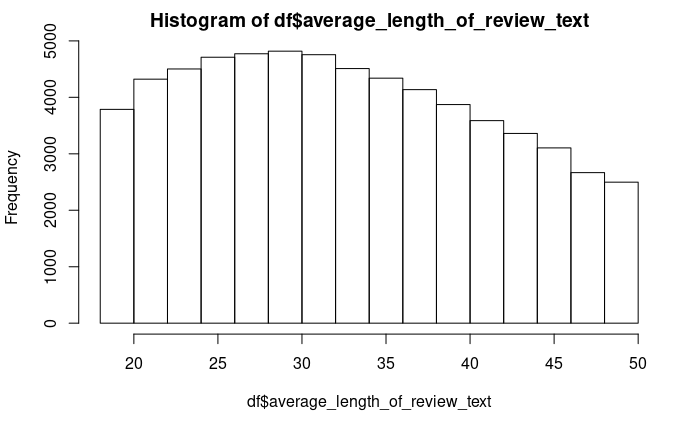

```r
df <- df %>% filter(df$average_length_of_review_text>18)
df <- df %>% filter(df$average_length_of_review_text<50)
df <- df %>% filter(df$overall_count>2)
hist(df$average_length_of_review_text)
```

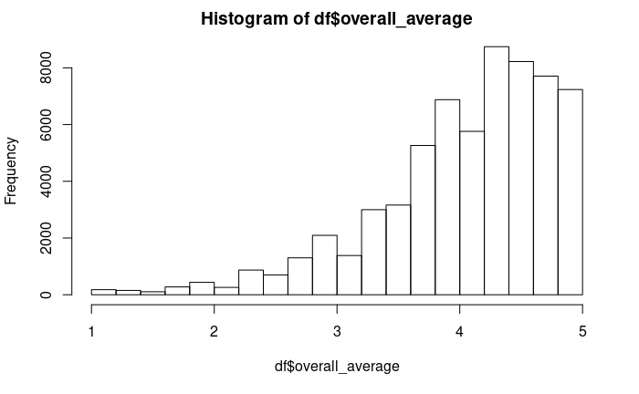

```r
hist(df$overall_average)
```

Again, the goal of this experiment is to see if there is a strong correlation between product average ranking and average review length. To see if there is a relationship, we now graph a random sample of 10000 products. For each product we will plot the product average ranking vs average review length. For this experiment, our dependent variable is average product ranking (y), and the independent variable (x) is average overall review length.

```r
df_sample <- sample_n(df, 10000)
plot(df_sample$average_length_of_review_text, df_sample$overall_average)
reg = lm(overall_average~average_length_of_review_text, data=df_sample)
abline(reg, col='Red')
```

```r
summary(reg)
```

```
Call:
lm(formula = overall_average ~ average_length_of_review_text,
    data = df_sample)

Residuals:
    Min      1Q  Median      3Q     Max
-3.1346 -0.3633  0.1585  0.5216  1.0261

Coefficients:
                                Estimate Std. Error t value Pr(>|t|)
(Intercept)                    4.2279782  0.0278492 151.817  < 2e-16 ***
average_length_of_review_text -0.0050938  0.0008247  -6.176 6.82e-10 ***
---
Signif. codes:  0 ‘***’ 0.001 ‘**’ 0.01 ‘*’ 0.05 ‘.’ 0.1 ‘ ’ 1

Residual standard error: 0.7182 on 9998 degrees of freedom
Multiple R-squared:  0.003801,  Adjusted R-squared:  0.003701
F-statistic: 38.15 on 1 and 9998 DF,  p-value: 6.822e-10
```

```r
par(mfrow=c(2,2))
```

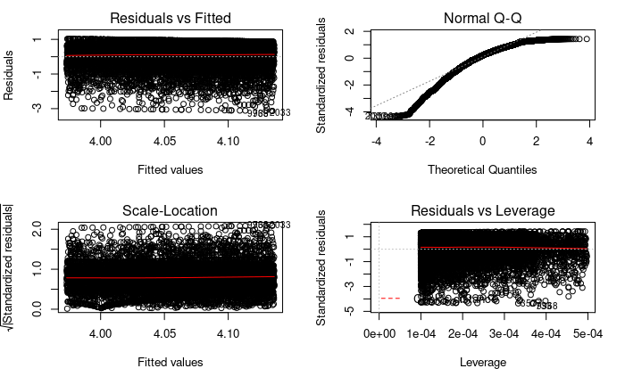

```r
plot(reg)
```

# Results

In this case, we have shown that while the review text length and the number of stars are correlated, they are NOT positively correlated.

In other words, we have failed to show that higher mean review text length is associated with consistenly higher ratings.